# Zadatak3 - glm

Marko Galavić

2026-06-10

## 1 Zadatak: Generalizirani linearni model

U zaglavlju upišite svoje ime i prezime pod *author: “Ime i prezime”*.

U datoteci se nalazi skup podataka s odzivnom varijablom `Y` i prediktorima `X1`, `X2`, `X3`, `X4` i `F1`. Varijabla `F1` je kvalitativna varijabla. Cilj je procijeniti prikladan generalizirani linearni model i interpretirati dobivene rezultate.

Ako je odzivna varijabla `Y` binarna, koristite logističku regresiju. Ako je odzivna varijabla `Y` brojevna varijabla, koristite Poissonovu regresiju.

1. Učitajte podatke i prikažite osnovni sažetak varijabli. Kratko komentirajte kakvog je tipa odzivna varijabla `Y` i koji ćete model koristiti.
2. Napravite barem jedan prikladan grafički prikaz koji pokazuje povezanost odzivne varijable `Y` s nekim od prediktora.
3. Procijenite puni generalizirani linearni model oblika
   $$Y \sim X1 + X2 + X3 + X4 + F1.$$
4. Na temelju funkcije `summary()` komentirajte koji su prediktori statistički značajni, a koji nisu.
5. Procijenite reducirani model u kojem izostavljate prediktor koji nije statistički značajan. Usporedite puni i reducirani model pomoću AIC vrijednosti. Koji biste model odabrali?
6. Napišite procijenjenu jednadžbu odabranog modela na odgovarajućoj skali:
   - za logističku regresiju na logit-skali,
   - za Poissonovu regresiju na log-skali.
7. Interpretirajte barem jedan koeficijent iz odabranog modela. Izračunajte i interpretirajte vrijednost $e^{\hat\beta}$.
8. Pomoću odabranog modela izračunajte predikcije za prva tri opažanja u skupu podataka. Koristite `predict(..., type = "response")` i objasnite što dobivene vrijednosti znače.
9. Ako koristite Poissonovu regresiju, dodatno izračunajte omjer
   $$\frac{\mathrm{deviance}}{\mathrm{df.residual}}$$
   i kratko komentirajte postoji li naznaka prekomjerne disperzije.

## 2 Uputa

U R-u logističku regresiju provodimo pomoću

```r
model <- glm(Y ~ X1 + X2 + X3 + X4 + F1, data = podaci, family = binomial)
```

Poissonovu regresiju provodimo pomoću

```r
model <- glm(Y ~ X1 + X2 + X3 + X4 + F1, data = podaci, family = poisson)
```

Procijenjene vrijednosti na originalnoj skali dobivamo pomoću

```r
predict(model, type = "response")
```

## 3 Rješenje

## 4 1. Učitavanje podataka i sažetak

```r
podaci <- read.csv("glm_pois_02.csv")

str(podaci)
```

```
## 'data.frame':    450 obs. of  6 variables:
##  $ Y : int  5 3 4 6 2 1 5 0 4 5 ...
##  $ X1: num  -0.2209 -0.0226 1.056 -0.4792 -0.1459 ...
##  $ X2: num  0.5314 1.7928 -0.2665 0.0775 0.4788 ...
##  $ X3: num  0.2419 0.0042 1.5809 1.4529 0.2832 ...
##  $ X4: num  1.18 1.39 -1.2 -2.7 1.16 ...
##  $ F1: chr  "A" "B" "A" "A" ...
```

```r
summary(podaci)
```

```
##        Y                X1                  X2                 X3
##  Min.   : 0.000   Min.   :-3.215300   Min.   :-3.39470   Min.   :-3.10270
##  1st Qu.: 1.000   1st Qu.:-0.693175   1st Qu.:-0.61670   1st Qu.:-0.63360
##  Median : 3.000   Median : 0.073750   Median :-0.05155   Median :-0.01415
##  Mean   : 3.478   Mean   : 0.001624   Mean   :-0.01519   Mean   :-0.02223
##  3rd Qu.: 5.000   3rd Qu.: 0.666775   3rd Qu.: 0.62325   3rd Qu.: 0.58140
##  Max.   :22.000   Max.   : 3.414600   Max.   : 3.58120   Max.   : 2.72350
##        X4                F1
##  Min.   :-3.09670   Length:450
##  1st Qu.:-0.58440   Class :character
##  Median :-0.00150   Mode  :character
##  Mean   : 0.05562
##  3rd Qu.: 0.79243
##  Max.   : 2.88370
```

```r
table(podaci$Y)
```

```
##
##  0  1  2  3  4  5  6  7  8  9 10 11 12 15 22
## 46 78 77 63 46 52 30 20 10  9  8  6  3  1  1
```

- `Y` je cijelobrojna varijabla (0, 1, 2, …), dakle radi se o broju događaja.
- Nije binarna, pa je prikladan **Poissonov GLM** s log-link funkcijom.

### 4.1 2. Grafički prikaz povezanosti Y s prediktorom

odnos `Y` i `X1`.

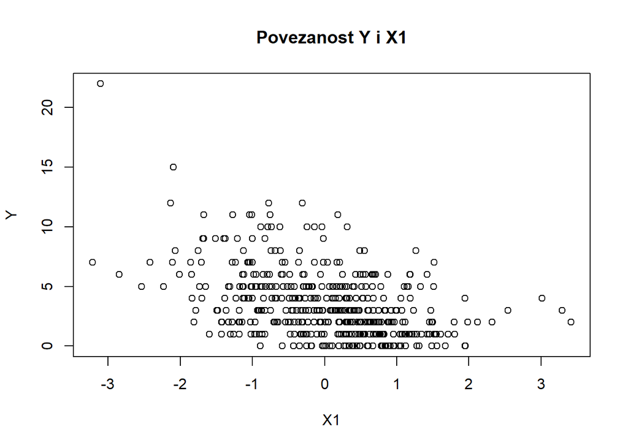

```r
plot(podaci$X1, podaci$Y,
     xlab = "X1", ylab = "Y",
     main = "Povezanost Y i X1")
```

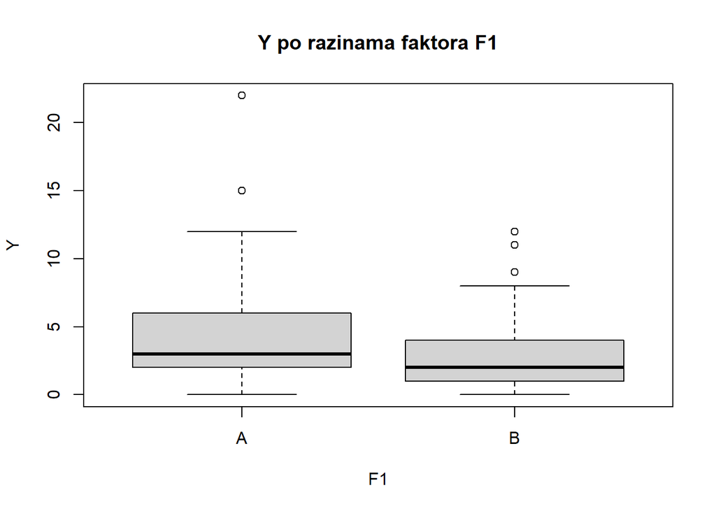

```r
boxplot(Y ~ F1, data = podaci,
        xlab = "F1", ylab = "Y",
        main = "Y po razinama faktora F1")
```

## 5 3. Puni Poissonov GLM

```r
model_full <- glm(Y ~ X1 + X2 + X3 + X4 + F1,
                  data = podaci,
                  family = poisson)

summary(model_full)
```

```
##
## Call:
## glm(formula = Y ~ X1 + X2 + X3 + X4 + F1, family = poisson, data = podaci)
##
## Coefficients:
##              Estimate Std. Error z value Pr(>|z|)
## (Intercept)  1.252581   0.034008  36.832  < 2e-16 ***
## X1          -0.382882   0.025213 -15.186  < 2e-16 ***
## X2           0.353089   0.025178  14.024  < 2e-16 ***
## X3           0.241092   0.027575   8.743  < 2e-16 ***
## X4          -0.006564   0.025976  -0.253    0.801
## F1B         -0.346711   0.053220  -6.515 7.28e-11 ***
## ---
## Signif. codes:  0 '***' 0.001 '**' 0.01 '*' 0.05 '.' 0.1 ' ' 1
##
## (Dispersion parameter for poisson family taken to be 1)
##
##     Null deviance: 1034.26  on 449  degrees of freedom
## Residual deviance:  544.38  on 444  degrees of freedom
## AIC: 1776.3
##
## Number of Fisher Scoring iterations: 5
```

Statistički značajni prediktori oni s `Pr(>|z|) < 0.05`  
- **Nije značajan:** `Pr(>|z|)` veći od 0.05 Prediktori X1, X2, X3 i F1 su statistički značajni (p < 0.05), dok X4 nije (p > 0.05).

## 6 5. Reducirani model i usporedba AIC

```r
model_red <- glm(Y ~ X1 + X2 + X3 + F1,
                 data = podaci,
                 family = poisson)

summary(model_red)
```

```
##
## Call:
## glm(formula = Y ~ X1 + X2 + X3 + F1, family = poisson, data = podaci)
##
## Coefficients:
##             Estimate Std. Error z value Pr(>|z|)
## (Intercept)  1.25233    0.03400  36.833  < 2e-16 ***
## X1          -0.38324    0.02519 -15.217  < 2e-16 ***
## X2           0.35295    0.02518  14.020  < 2e-16 ***
## X3           0.24162    0.02749   8.788  < 2e-16 ***
## F1B         -0.34708    0.05320  -6.524 6.85e-11 ***
## ---
## Signif. codes:  0 '***' 0.001 '**' 0.01 '*' 0.05 '.' 0.1 ' ' 1
##
## (Dispersion parameter for poisson family taken to be 1)
##
##     Null deviance: 1034.26  on 449  degrees of freedom
## Residual deviance:  544.44  on 445  degrees of freedom
## AIC: 1774.4
##
## Number of Fisher Scoring iterations: 5
```

```r
AIC(model_full)
```

```
## [1] 1776.341
```

```r
AIC(model_red)
```

```
## [1] 1774.405
```

Bolji model onaj s manjim AIC. Usporedbom AIC vrijednosti, reducirani model ima manji AIC, pa ga odabiremo kao prikladniji.

## 8 8. Predikcije za prva tri opažanja

```r
preds <- predict(model_red, type = "response")
head(preds, 3)
```

```
##        1        2        3
## 4.869502 4.700639 3.112870
```

Model predviđa da je očekivani broj događaja Y za prvo opažanje 4.869, za drugo 4.700 i treće je 3.112

## 9 9. Provjera prekomjerne disperzije

```r
model_red$deviance
```

```
## [1] 544.444
```

```r
model_red$df.residual
```

```
## [1] 445
```

```r
disp_ratio <- model_red$deviance / model_red$df.residual
disp_ratio
```

```
## [1] 1.22347
```